# Classes

Python merupakan bahasa pemrograman yang berbasis Object. Object adalah suatu variabel dengan tipe data class yang tidak hanya berisi nilai atau state atau property, tetapi object juga memiliki method atau fungsi-fungsi yang melekat pada object tersebut dan dapat juga merubah nilai object tersebut.  
Berikut beberapa hal yang harus diketahui untuk Pengenalan Pemrograman Berorientasi Obyek (PBO):

1. String dan List
2. Istilah dalam PBO
3. Constructor
4. Method
5. Override Method

### String dan List

Contoh tipe data class yang sudah dikenal, dan digunakan sebelumnya, adalah tipe data lists ataupun string. Suatu variabel yang berbentuk lists ataupun string, memiliki dua buah elemen yang terkandung di dalam variabel tersebut, yaitu nilai atau yang disebut dengan state/property, serta method atau fungsi, yang dapat digunakan untuk mengolah nilai pada variabel tersebut. Method atau fungsi yang melekat pada suatu variabel dapat diakses dengan menggunakan syntax  
namaObyek.NamaMethod()

## Code

Berikut adalah contoh tipe data string dan lists, yang memiliki nilai sekaligus method

```python
# String

dataStr='Struktur Data'
print(dataStr)
dataStr=dataStr.upper()
print(dataStr)
```

```
Struktur Data
STRUKTUR DATA
```

```python
# Lists
dataLs=[4,10,21]
print(dataLs)
dataLs.append(45)
print(dataLs)
```

```
[4, 10, 21]
[4, 10, 21, 45]
```

### Istilah dalam Pemrograman Berorientasi Obyek

Kelebihan dari bahasa pemrogaraman berbasis object, adalah bahasa tersebut menyediakan beberapa fitur agar programmer dapat membuat class sendiri yang sesuai dengan kebutuhan. Beberapa istilah dasar yang terdapat pada pemrograman berbasis object ini antara lain :

- class, tipe data yang tidak hanya berisi data tetapi juga method
- object, suatu variabel dengan tipe data class
- state, property, bagian data dari suatu class yang berisi nilai, dapat berupa string, integer, float
- method, fungsi yang melekat pada class
- constructor, fungsi yang dijalankan oleh python ketika pertama kali suatu objek dibuat. Method constructor ini dibuat dengan cara mendefinisikan fungsi _ init _ (dua underscore)
- self, merupakan suatu argumen atau parameter spesial agar nilai balik dari method dikembalikan ke objek itu sendiri. Argumen ini tidak perlu dipanggil (walaupun sudah didefinisikan)pada saat pemanggilan method
- instance, suatu objek yang telah dibuat
- override, mendefinisikan kembali fungsi-fungsi umum yang sudah ada, agar sesuai dengan kebutuhan programmer

### Constructor

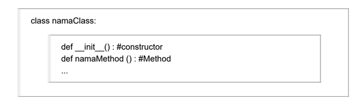

Sedangkan untuk membuat suatu obyek dengan tipe data class tertentu (proses pembuatan instance) adalah :  
namaObyek=namaClass()  
Constructor merupakan method yang otomatis dijalankan ketika suatu obyek dibuat. Syntax untuk pembuatan constructor ini adalah :  
def **init**()

### Code

Berikut adalah contoh pembuatan tipe data ini dimulai dari mendefinisikan class dan membuat constructor dari class tersebut. Class yang akan dibuat adalah class bilangan kompleks, dimana setiap bilangan kompleks memiliki dua buah nilai, yaitu bagian real, dan bagian imajiner.

```python
class BilanganKompleks:
    def __init__(self,a,b):
        self.real=a
        self.im=b
```

```python
data=BilanganKompleks(4,6)
type(data)
```

```
__main__.BilanganKompleks
```

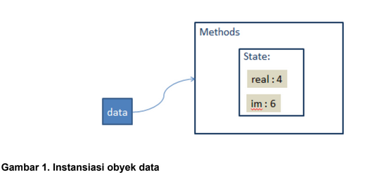

Pada contoh code sebelumnya, dilakukan syntax type(data) yaitu untuk mengetahui tipe data dari variabel data. Misalkan isi dari data tersebut ingin ditampilkan, maka tidak bisa dilakukan dengan cara menulis syntax print seperti biasa, Jika tetap perintahkan print untuk menampilkan data tersebut, maka yang ditampilkan di layar hanyalah alamat tempat data tersebut disimpan, seperti contoh code berikut.

### Code

```python
class BilanganKompleks:
    def __init__(self,a,b):
    self.real = a
    self.im = b


data=BilanganKompleks(4,6)
print(data)
```

[output not shown]

Oleh karena itu, untuk menampilkan property atau nilai yang dimiliki oleh suatu obyek, tidak dapat dilakukan dengan syntax print() seperti biasa. Terdapat dua cara agar objek yang sudah dibuat dapat ditampilkan di layar sesuai dengan yang diinginkan, yaitu:

- Membuat method baru untuk menampilkan data
- override method standar dari sebuah class

### Method

Method merupakan fungsi-fungsi yang terdapat di dalam suatu class. Contoh method yang akan dibuat adalah method yang berfungsi untuk menampilkan property atau state yang terdapat di dalam suatu obyek. Syntax pembuatan method adalah :  
def namaMethod():  
Sedangkan untuk memanggil method suatu class adalah :  
namaObyek.namaMethod()

### Code

```python
class BilanganKompleks:
    def __init__(self,a,b): # constructor
        self.real=a
        self.im=b
    def display(self): # method untuk menampilkan state
        print (self.real,'+',self.im,'i')
```

```python
data1=BilanganKompleks(4,6)
data1.display()
data2=BilanganKompleks(2,3)
data2.display()
```

```
4 + 6 i
2 + 3 i
```

### Override Method

Override Method merupakan penambahan fungsi-fungsi pada syntax-syntax yang sudah ada. Seperti yang dijelaskan sebelumnya, untuk menampilkan property yang terdapat pada suatu obyek, tidak dapat dilakukan dengan menggunakan perintah print() . Cara pertama yang sudah dijelaskan adalah membuat method baru di dalam class, yang berfungsi untuk menampilkan property suatu class. Cara kedua adalah dengan cara override method fungsi yang sudah tersedia oleh bahasa pemrograman. Syntax yang akan dioverride adalah syntax print() . Yang perlu dilakukan agar suatu object dapat dipanggil dengan perintah print adalah object tersebut harus dirubah menjadi string. Untuk merubah suatu variabel menjadi string, maka suatu class dilengkapi dengan method **str** . Hanya saja method ini tidak bisa berfungsi secara sempurna sesuai dengan apa yang diinginkan oleh programmer, yaitu agar syntax print dapat digunakan langsung untuk menampilkan property yang terdapat pada suatu class.

### Code

```python
class BilanganKompleks:
    def __init__(self,a,b):
        self.real=a
        self.im=b
    def display(self):
        print (self.real,"+",self.im,"i")
    def __str__(self):
        return str(self.real)+" + "+str(self.im)+" i "
```

```python
data1=BilanganKompleks(4,6)
data2=BilanganKompleks(2,5)
```

```python
print('Override Method')
print(data1)
print(data2)
print('Method dalam Class')
data1.display()
data2.display()
```

```
Override Method
4 + 6 i
2 + 5 i
Method dalam Class
4 + 6 i
2 + 5 i
```

Penjumlahan dua buah bilangan kompleks berbeda dengan penjumlahan bilangan yang lain, karena bilangan kompleks ini terdiri dari dua bagian yaitu real dan imajiner. Untuk menjumlahkan bilangan kompleks, maka bagian real harus dijumlahkan pada bagian real juga dari bilangan lain, dan bagian imajiner harus ditambahkan dengan bagian imajiner, seperti persamaan berikut:

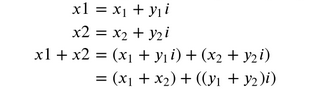

Seperti halnya fungsi untuk menampilkan property yang terdapat pada suatu class, maka untuk melakukan operasi penjumlahan ini juga dapat dilakukan dengan dua buah cara, yaitu :

- Membuat metode di dalam class untuk operasi penjumlahan
- Override method

```python
class BilanganKompleks:
    def __init__(self,a,b):
        self.real=a
        self.im=b
    def display(self):
        print (self.real,'+',self.im,'i')
    def __str__(self):
        return str(self.real) + " + " + str(self.im) + " i "
    def addKompleks(self,obj):
        a=self.real+obj.real
        b=self.im+obj.im
        return BilanganKompleks(a,b)
```

```python
data1=BilanganKompleks(4,6)
data2=BilanganKompleks(2,5)
```

```python
jumlah=data1.addKompleks(data2)
data1.display()
data2.display()
print(jumlah)
```

```
4 + 6 i
2 + 5 i
6 + 11 i
```

Jika ingin melakukan operasi penjumlahan dengan menggunakan operator '+', maka tidak dapat langsung dilakukan perintah sebagai berikut :  
data1=BilanganKompleks(4,6)  
data2=BilanganKompleks(2,5)  
jumlah=data1+data2  
Operasi penjumlahan dengan operator '+' hanya dapat dilakukan dengan override fungsi **add** yang sudah tersedia.

```python
class BilanganKompleks:
    def __init__(self,a,b):
        self.real=a
        self.im=b
    def display(self):
        print (self.real,'+',self.im,'i')
    def __str__(self):
        return str(self.real) + " + " + str(self.im) + " i "
    def addKompleks(self,obj):
        a=self.real+obj.real
        b=self.im+obj.im
        return BilanganKompleks(a,b)
    def __add__(self,obj):
        a=self.real+obj.real
        b=self.im+obj.im
        return BilanganKompleks(a,b)
```

```python
data1=BilanganKompleks(4,6)
data1=BilanganKompleks(5,10)
jumlah=data1+data2
print(data1)
print(data2)
print(jumlah)
```

```
5 + 10 i
2 + 5 i
7 + 15 i
```

Perkalian dua bilangan kompleks juga berbeda dengan perkalian bilangan biasa, karena keistimewaan bilangan kompleks ini. Perkalian dua buah bilangan kompleks dapat dilakukan sebagai berikut :

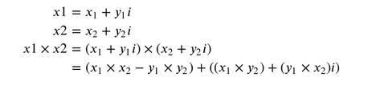

### Code

```python
class BilanganKompleks:
    def __init__(self,a,b):
        self.real=a
        self.im=b
    def display(self):
        print (self.real,'+',self.im,'i')
    def __str__(self):
        return str(self.real) + " + " + str(self.im) + " i "
    def addKompleks(self,obj):
        a=self.real+obj.real
        b=self.im+obj.im
        return BilanganKompleks(a,b)
    def __add__(self,obj):
        a=self.real+obj.real
        b=self.im+obj.im
        return BilanganKompleks(a,b)
    def __mul__(self,data):
        temp1=(self.real*data.real)-(self.im*data.im)
        temp2=(self.real*data.im)+(data.real*self.im)
        return BilanganKompleks(temp1,temp2)
```

```python
a=BilanganKompleks(4,6)
b=BilanganKompleks(5,10)
c=a * b
print(a)
print(b)
print(c)
```

```
4 + 6 i
5 + 10 i
-40 + 70 i
```

# Linked List

Bahasa pemrograman python telah menyediakan type data yang dinamis, yaitu List. Ukuran dari variabel yang bertipe data list dapat diatur sesuai dengan keinginan programmer selama program dijalankan, tidak harus mempunyai ukuran tetap di awal. Tipe data ini juga menyediakan method menambah data pada saat diperlukan, sehingga tipe data ini bersifat dinamis.  
Akan tetapi tidak semua pemrograman menyediakan type data seperti ini, oleh karena itu terdapat suatu struktur data yang dapat dibuat oleh programmer yang bersifat dinamis, yaitu Linked List.  
Lima hal utama yang terdapat pada struktur data linked list:

1. Node
2. Linked List
3. Penambahan Data pada Linked List
4. Traversal Linked List
5. Ordered List

### Node

Data di dalam memory berada di alamat yang berbeda-beda, jika dibutuhkan agar data-data tersebut dapat terhubung satu sama lain, maka informasi tambahan yang menunjukkan alamat data berikutnya sangatlah diperlukan, seperti yang terlihat pada Gambar 1 berikut.

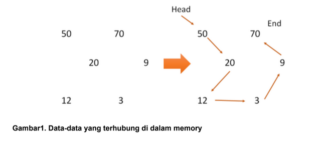

Oleh karena itu data berikutnya dapat diketahui dengan cari mengikuti informasi link yang terdapat pada informasi tambahan tersebut. Lokasi data pertama dari linked list haruslah diketahui secara eksplisit, sehingga dari data pertama tersebut, data kedua data ditemukan, data ketiga, dan seterusnya. Informasi yang menunjuk pada lokasi data pertama atau head of the list tersebut disebut dengan external reference. Begitu juga dengan data terakhir, harus ada informasi yang menunjukkan bahwa data tersebut adalah data terakhir di dalam linked list, tidak ada lagi data berikutnya. Untuk membuat struktur data linked list, terlebih dahulu dibuat node-node penyusun linked list tersebut. Node ini harus memiliki setidaknya dua informasi, yaitu informasi mengenai data atau nilai, dan informasi mengenai node berikutnya. Oleh karena itu node dibuat menjadi sebuah tipe data baru yang bertipe class, dengan dua informasi yaitu data dan next.  
Terdapat beberapa method penting pada class node ini, antara lain:

- constructor, yang akan dijalankan setiap instansiasi class
- getData, untuk mengetahui informasi data yang terdapat pada node tersebut
- getNext, untuk mengetahui informasi node berikutnya, jika tidak ada node berikutnya maka nilai balik berupa None
- setData, untuk merubah informasi data yang terdapat pada node tersebut
- setNext, untuk menentukan node berikutnya yang ditunjukan oleh informasi next dari node tersebut  
  Contoh Node dapat dilihat pada Gambar 2.

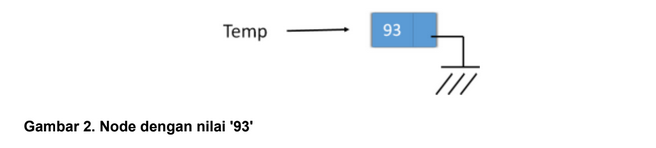

  Pada Gambar 2 tersebut, terdapat dua informasi yang terkandung di dalam node, yaitu data dari node adalah 93, dan node tersebut menunjuk ke Nil atau Ground atau tidak ada node yang ditunjuk.

### Code

Berikut adalah pembuatan class Node yang merupakan representasi dari sebuah node. Property atau state yang terdapat pada class Node ini :

1. data : berisi nilai dari node
2. next : berisi informasi berikutnya yang ditunjuk oleh node. Proses intansiasi, property next ini diset None yang merupakan representasi Nil atau Ground, berarti tidak ada node yang ditunjuk oleh node ini

```python
class Node:
    def __init__(self, init_data):
        self.data = init_data
        self.next = None
    def getData(self):
        return self.data
    def getNext(self):
        return self.next
    def setData(self, newdata):
        self.data = newdata
    def setNext(self, new_next):
        self.next = new_next
```

```python
a=Node(93)
b=Node(20)
print(a.getNext())
print(b.getNext())
a.setNext(b)
print(a.getNext())
```

```
None
None
<__main__.Node object at 0x000001F134F42FD0>
```

Pada code diatas, terdapat obyek a dan obyek b yang memiliki tipe data class Node . Pada saat instansiasi, property data kedua obyek ini bernilai 93 dan 20 , serta property next bernilai None. Pada baris kelima, terdapat perintah a.setNext(b) , yang berarti property next dari obyek a akan menunjuk ke obyek b . Sehingga ketika dilakukan perintah print(a.getNext()) akan menunjukkan ke suatu class Node.

### Linked List Class

Linked list merupakan kumpulan dari node-node yang terhubung satu sama lain. Untuk mengakses node-node yang terdapat pada linked list tersebut, haruslah diketahui terlebih dahulu lokasi node pertama dari suatu linked list, sehingga diperlukan pointer tambahan untuk menunjukkan keberadaan node pertama.

### Code

Berikut adalah class untuk linked list, dimana pada class tersebut terdapat pointer yang menunjukkan node pertama dari suatu linked list (head). Terdapat dua buah method utama pada class LinkedList ini, antara lain:

1. constructor, **init** , yang merupakan method yang dijalankan pada saat pembuatan obyek. Karena obyek baru pertama kali dibuat, maka linked list masih kosong, sehingga pointer head masih bernilai None.
2. Method isEmpty , untuk pengecekan apakah linked list memiliki node ataukah tidak. Jika pointer head masih menunjuk pada None, maka linked list masih tidak memiliki node, sehingga return value adalah True.

```python
class LinkedList:
    def __init__(self):
        self.head = None
    def isEmpty(self):
        return self.head==None
```

```python
mylist=LinkedList()
```

```python
print(mylist.head)
mylist.isEmpty()
```

```
None
```

```
True
```

```python
print(mylist.head)
```

```
None
```

```python
mylist.isEmpty()
```

```
True
```

Obyek mylist yang telah dibuat pada code diatas yang bertipe linked list, adalah linked list yang masih kosong, belum ada node dalam list tersebut, seperti yang ditunjukkan pada Gambar 3.

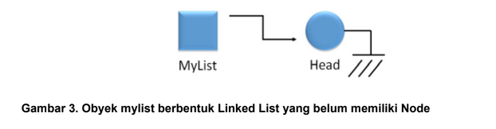

### Penambahan Data pada Linked List

Secara default, penambahan data baru diletakkan pada awal linked list atau yang terdapat pada pointer head. Penambahan data baru ini, dilakukan dengan dua tahapan :

- Tautkan node baru ini ke node awal dari linked list
- modifikasi head dari linked list agar menunjuk pada node baru ini, seperti yang ditunjukkan pada Gambar 4 berikut :

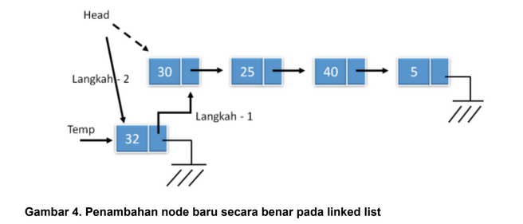

  Urutan tahapan ini tidak boleh dibalik, karena jika dibalik maka linked list yang awal tidak lagi dapat ditemukan seperti yang terdapat pada Gambar 5 berikut :

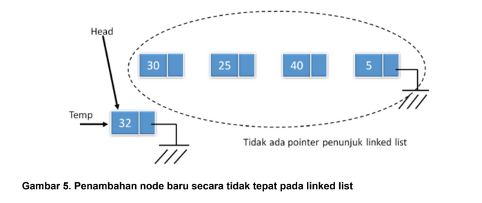

### Code

Berikut adalah penambahan method add() pada class LinkedList. Seperti yang dijelaskan sebelumnya, penambahan node baru harus dilakukan dengan urutan yang tepat, yaitu:  
temp=Node(item) #temp adalah node baru yang akan ditambahkan temp.setNext(self.head) #pointer Next dari node temp menunjuk pada node yang ditunjuk oleh pointer head self.head=temp #pointer head menunjuk pada node temp yang sudah tersambu ng dengan linked list

```python
class LinkedList:
    def __init__(self):
        self.head = None
    def isEmpty(self):
        return self.head==None
    def add(self, item):
        temp = Node(item)
        temp.setNext(self.head)
        self.head = temp
```

```python
mylist=LinkedList()
```

```python
print(mylist.head)
mylist.isEmpty()
```

```
None
```

```
True
```

```python
mylist.add(34)
print(mylist.head)
```

```
<__main__.Node object at 0x000001F134F42E90>
```

```python
mylist.add(45)
print(mylist.head)
print(mylist.head.data)
```

```
<__main__.Node object at 0x000001F13507EEA0>
45
```

```python
mylist.add(21)
```

### Traversal Linked List

Untuk mengetahui ukuran dari list, diperlukan tahapan traverse, yaitu menelusuri setiap node yang terdapat pada linked list, seperti pada Gambar 6 sebagai berikut :

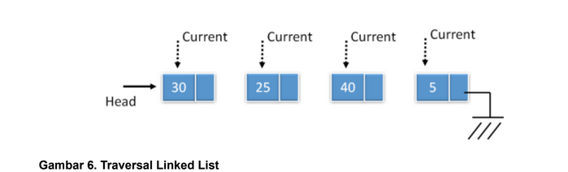

Pada proses penelusuran atau traversal dibutuhkan pointer bantuan. Pointer bantuan yang ditunjukkan pada Gambar 6 tersebut, adalah pointer curent yang bergerak dari node awal sampai dengan node akhir. Proses traversal ini dibutuhkan untuk beberapa hal, seperti untuk menghitung jumlah node yang terdapat pada Linked List, untuk mencari node pada linked list, untuk menampilkan seluruh node dari linked list, untuk menyisipkan node setelah atau sebelum node yang sudah terdapat pada linked list, dan untuk menghapus suatu node.

### Code

Implementasi pertama yang dibuat adalah pembuatan method size(), untuk menghitung jumlah node. Pada method size terdapat beberapa tahapan :

1. pointer bantuan curent berada pada node yang ditunjuk oleh head (yaitu node pertama)
2. pointer curent bergerak, dengan perintah curent=curent.getNext() , sekaligus dilakukan increment variabel count, yang merepresentasikan jumlah node
3. pergerakan atau traversal ini akan berakhir ketika pointer curent menunjuk pada None, yang merepresentasikan, tidak ada lagi node yang terdapat pada Linked list

```python
class LinkedList:
    def __init__(self):
        self.head = None
    def isEmpty(self):
        return self.head==None
    def add(self, item):
        temp = Node(item)
        temp.setNext(self.head)
        self.head = temp
    def size(self):
        curent = self.head
        count = 0
        while curent != None:
            count = count + 1


            curent = curent.getNext()
        return count
```

```python
mylist=LinkedList()
mylist.add(45)
mylist.add(34)
mylist.add(70)
print(mylist.size())
```

```
3
```

### Pencarian Node pada Linked List

Untuk pencarian node di dalam linked list juga perlu dilakukan traverse linked list seperti sebelumnya, hanya saja setiap berada pada suatu node, maka dilakukan pencocokan apakah node tersebut adalah node yang dicari, seperti Gambar 7 berikut:

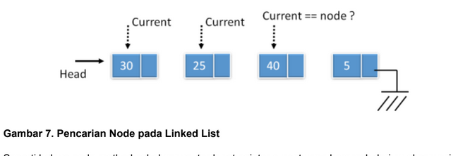

Seperti halnya pada method sebelumnya, terdapat pointer curent yang bergerak dari awal sampai akhir, hanya saja diperlukan pencocokan antara data yang terdapat pada curent dengan data yang dicari. Implementasi pencarian dapat dilihat pada method berikut

### Code

Berikut penambahan method search() pada class LinkedList. Method search() ini hampir sama dengan method size , hanya saja jika ditambahkan apakah node yang ditunjukkan oleh pointer curent adalah node yang dicari, dengan perintah:

if curent.getData() == item: #dimana item adalah node yang dicari

maka method ini akan menghasilkan nilai True.

```python
class LinkedList:
    def __init__(self):
        self.head = None
    def isEmpty(self):
        return self.head==None
    def add(self, item):
        temp = Node(item)
        temp.setNext(self.head)
        self.head = temp
    def size(self):
        curent = self.head
        count = 0
        while curent != None:
            count = count + 1
            curent = curent.getNext()
        return count
    def search(self,item):
        curent = self.head
        found = False
        while curent != None and not found:
            if curent.getData() == item:
                found = True
            else:
                curent = curent.getNext()
        return found
```

```python
mylist=LinkedList()
mylist.add(45)
mylist.add(34)
mylist.add(70)
mylist.add(84)
mylist.size()
mylist.search(34)
```

```
True
```

### Menampilkan seluruh data pada Linked list

Proses traversal juga dapat digunakan untuk menampilkan data pada seluruh node yang terdapat pada Linked List.

### Code

Berikut method display() untuk menampilkan data dari seluruh node pada linked list

```python
class LinkedList:
    def __init__(self):
        self.head = None
    def isEmpty(self):
        return self.head==None
    def add(self, item):
        temp = Node(item)
        temp.setNext(self.head)
        self.head = temp
    def size(self):
        curent = self.head
        count = 0
        while curent != None:
            count = count + 1
            curent = curent.getNext()
        return count
    def search(self,item):
        curent = self.head
        found = False
        while curent != None and not found:
            if curent.getData() == item:
                found = True
            else:
                curent = curent.getNext()
        return found
    def display(self):
        curent = self.head
        while curent != None:
            print(curent.getData())
            curent = curent.getNext()
```

```python
mylist=LinkedList()
mylist.add(45)
mylist.add(34)
mylist.add(70)
mylist.add(84)
```

```python
mylist.display()
```

```
84
70
34
45
```

### Penghapusan Node pada Linked List

Penghapusan data (remove data) dilakukan dengan dua tahapan yaitu :

- traverse linked list, untuk mencari node mana yang akan dihapus
- remove data, menghapus node dari linked list

Untuk traverse linked list sama hal nya dengan method sebelumnya, yaitu terdapat pointer curent yang menelusuri node awal sampai dengan node akhir untuk mencari node yang akan dihapus. Ketika node sudah ditemukan, penghapusan tidak dapat dilakukan langsung begitu saja, karena di dalam node terdapat informasi lain, yaitu next yang menunjukkan lokasi node berikutnya. Sebelum dilakukan penghapusan perlu dilakukan terlebih dahulu pentautan antara node sebelum node yang dicari dengan node sesudah node yang dicari, sehingga node yang dicari dapat dihapus. Oleh karena itu diperlukan pointer tambahan selain curent, yaitu pointer previous. Pointer ini bergerak satu langkah sebelum pointer curent, sehingga ketika pointer curent sudah menemukan data yang dicari, maka pointer previous ini dapat ditautkan dengan node sesudah curent. Ilustrasi ketika data yang akan dihapus berada di tengah linked list ditunjukkan pada Gambar 8.

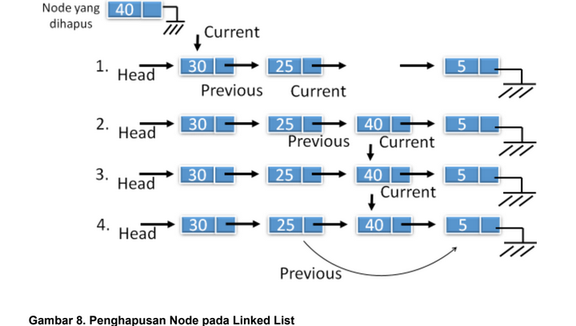

Jika data yang dihapus berada di node awal dari linked list (yang ditunjukkan dengan nilai previous masih None, maka yang dilakukan pointer head langsung menunjuk pada node setelah node yang akan dihapus tersebut, seperti Gambar 9 berikut:

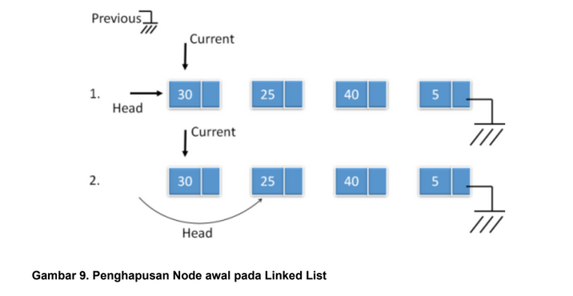

### Code

Berikut adalah penambahan method remove() untuk menghapus node yang diinginkan pada linked list

```python
class LinkedList:
    def __init__(self):
        self.head = None
    def isEmpty(self):
        return self.head==None
    def add(self, item):
        temp = Node(item)
        temp.setNext(self.head)
        self.head = temp
    def size(self):
        curent = self.head
        count = 0
        while curent != None:
            count = count + 1
            curent = curent.getNext()
        return count
    def search(self,item):
        curent = self.head
        found = False
        while curent != None and not found:
            if curent.getData() == item:
                found = True
            else:
                curent = curent.getNext()
        return found
    def display(self):
        curent = self.head
        while curent != None:
            print(curent.getData())
            curent = curent.getNext()
    def remove(self, item):
        curent = self.head
        previous = None
        found = False
        while not found:
            if curent.getData() == item:
                found = True
            else:
                previous = curent
                curent = curent.getNext()
        if previous == None:
            self.head = curent.getNext()
        else:
            previous.setNext(curent.getNext())
```

```python
mylist=LinkedList()
mylist.add(45)
mylist.add(34)
mylist.add(70)
mylist.add(84)
mylist.add(97)
mylist.display()
```

```
97
84
70
34
45
```

```python
mylist.remove(34)
```

```python
mylist.display()
```

```
97
84
70
45
```

# Ordered List

Proses pencarian pada linked list sebelumnya dilakukan dengan cara mencari node satu persatu sampai node terakhir. Proses pencarian ini akan menjadi lebih cepat jika data sudah dalam keadaan terurut, sehingga pencarian dapat dihentikan ketika ditemukan node dengan data lebih rendah atau lebih tinggi. Class Ordered List akan memudahkan pencarian suatu node, karena data yang terdapat pada class ini sudah dalam keadaan terurut.

Method yang terdapat pada ordered list, sama halnya dengan class linkedlist, hanya saja terdapat perbedaan pada method untuk add data (karena node yang terbentuk harus dalam keadaan terurut), dan method search data.

### Code

Berikut method untuk class ordered list

```python
class OrderedLinkedList:
    def __init__(self):
        self.head = None
    def isEmpty(self):
        return self.head==None
    def size(self):
        curent = self.head
        count = 0
        while curent != None:
            count = count + 1
            curent = curent.getNext()
        return count
    def display(self):
        curent = self.head
        while curent != None:
            print(curent.getData())
            curent = curent.getNext()
    def remove(self, item):
        curent = self.head
        previous = None
        found = False
        while not found:
            if curent.getData() == item:
                found = True
            else:
                previous = curent
                curent = curent.getNext()
        if previous == None:
            self.head = curent.getNext()
        else:
            previous.setNext(curent.getNext())
    def search(self,item):
        curent = self.head
        found = False
        stop=False
        while curent != None and not found and not stop:
            if curent.getData() == item:
                found = True
            else:
                if curent.getData() > item:
                    stop = True
                else:
                    curent = curent.getNext()
        return found
    def add(self, item):
        curent=self.head
        previous = None
        stop = False
        while curent != None and not stop:
            if curent.getData() > item:
                stop = True
            else:
                previous = curent
                curent = curent.getNext()
                temp = Node(item)
                if previous == None:
                    temp.setNext(self.head)
                    self.head = temp
                else: # ditautkan antara previous dengan curent
                    temp.setNext(curent)
                    previous.setNext(temp)
```

```python
myList=OrderedLinkedList()
myList.add(9)
myList.add(14)
myList.display()
```

```python
myList.add(100)
myList.display()
```